# Exploring Malaria Fatality Data

## What is Malaria?

#### Source: WHO https://www.who.int/news-room/fact-sheets/detail/malaria

Malaria is an acute febrile illness caused by Plasmodium parasites, which are spread to people through the bites of infected female Anopheles mosquitoes. There are 5 parasite species that cause malaria in humans, and 2 of these species – P. falciparum and P. vivax – pose the greatest threat. P. falciparum is the deadliest malaria parasite and the most prevalent on the African continent. P. vivax is the dominant malaria parasite in most countries outside of sub-Saharan Africa.

The first symptoms – fever, headache and chills – usually appear 10–15 days after the infective mosquito bite and may be mild and difficult to recognize as malaria. Left untreated, P. falciparum malaria can progress to severe illness and death within a period of 24 hours.

```python
import pandas as pd
import matplotlib.pyplot as plt
import matplotlib.style as style
import seaborn as sns
from matplotlib.ticker import FuncFormatter
```

```python
mal_rate = pd.read_csv("C:/Users/hunte/Desktop/R_Malaria/malaria-death-rates.csv")
mal_age = pd.read_csv("C:/Users/hunte/Desktop/R_Malaria/malaria-deaths-by-age.csv")
```

```python
mal_rate.head()
```

|  | Entity | Year | DeathRate |
| --- | --- | --- | --- |
| 0 | Afghanistan | 1990 | 0.83 |
| 1 | Afghanistan | 1991 | 1.57 |
| 2 | Afghanistan | 1992 | 1.75 |
| 3 | Afghanistan | 1993 | 0.71 |
| 4 | Afghanistan | 1994 | 1.35 |

```python
mal_age.head()
```

|  | Entity | Year | Deaths-70-Plus | Deaths-50-69 | Deaths-15-49 | Deaths-5-14 | Deaths-Under-5 |
| --- | --- | --- | --- | --- | --- | --- | --- |
| 0 | Afghanistan | 1990 | 5 | 19 | 46 | 3 | 21 |
| 1 | Afghanistan | 1991 | 11 | 38 | 94 | 6 | 41 |
| 2 | Afghanistan | 1992 | 12 | 44 | 125 | 8 | 51 |
| 3 | Afghanistan | 1993 | 5 | 17 | 58 | 3 | 24 |
| 4 | Afghanistan | 1994 | 9 | 33 | 110 | 7 | 52 |

## Map of the World Health Organization's African Region

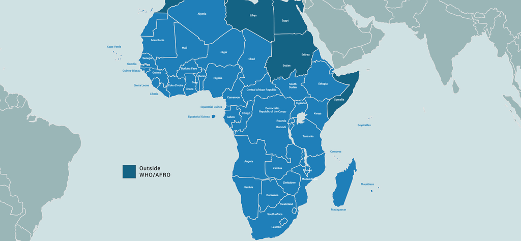

### View under-5 deaths in the African Region

```python
africa_under_five = mal_age.loc[mal_age['Entity'] == 'African Region (WHO)',['Entity','Year','Deaths-Under-5']]

africa_under_five.head()
```

|  | Entity | Year | Deaths-Under-5 |
| --- | --- | --- | --- |
| 30 | African Region (WHO) | 1990 | 447410 |
| 31 | African Region (WHO) | 1991 | 459072 |
| 32 | African Region (WHO) | 1992 | 465937 |
| 33 | African Region (WHO) | 1993 | 476788 |
| 34 | African Region (WHO) | 1994 | 483003 |

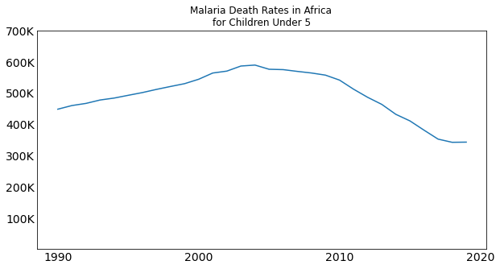

```python
africa_under_five.plot(x="Year", y="Deaths-Under-5",figsize=(10,5))

plt.title("Malaria Death Rates in Africa \nfor Children Under 5")
plt.style.use('fivethirtyeight')
plt.xlabel('')
plt.legend([], frameon=False)

ax = plt.gca()
ax.tick_params(axis='both', colors='black', labelsize=14, length=0)

ax.set_yticks([0,100000,200000,300000,400000,500000,600000,700000])

g = ax.get_yticks()
plt.yticks(g[1:])
ax.get_yaxis().set_major_formatter(
    FuncFormatter(lambda y,p: format(str(int(y/1000))+'K')))

ax.set_xticks([1990,2000,2010,2020])


plt.show()
```

### Compare under-5 deaths to deaths for age 5 and over.

```python
# First create a new column with sum of older deaths

mal_age['Deaths-5-Plus'] = (mal_age['Deaths-70-Plus'] + mal_age['Deaths-50-69'] + mal_age['Deaths-15-49'] + mal_age['Deaths-5-14'])
mal_age.head()
```

|  | Entity | Year | Deaths-70-Plus | Deaths-50-69 | Deaths-15-49 | Deaths-5-14 | Deaths-Under-5 | Deaths-5-Plus |
| --- | --- | --- | --- | --- | --- | --- | --- | --- |
| 0 | Afghanistan | 1990 | 5 | 19 | 46 | 3 | 21 | 73 |
| 1 | Afghanistan | 1991 | 11 | 38 | 94 | 6 | 41 | 149 |
| 2 | Afghanistan | 1992 | 12 | 44 | 125 | 8 | 51 | 189 |
| 3 | Afghanistan | 1993 | 5 | 17 | 58 | 3 | 24 | 83 |
| 4 | Afghanistan | 1994 | 9 | 33 | 110 | 7 | 52 | 159 |

```python
mal_age_compare = mal_age.loc[mal_age['Entity'] == 'African Region (WHO)',['Entity','Year','Deaths-Under-5','Deaths-5-Plus']]
mal_age_compare
```

|  | Entity | Year | Deaths-Under-5 | Deaths-5-Plus |
| --- | --- | --- | --- | --- |
| 30 | African Region (WHO) | 1990 | 447410 | 141099 |
| 31 | African Region (WHO) | 1991 | 459072 | 148258 |
| 32 | African Region (WHO) | 1992 | 465937 | 154509 |
| 33 | African Region (WHO) | 1993 | 476788 | 162147 |
| 34 | African Region (WHO) | 1994 | 483003 | 167970 |
| 35 | African Region (WHO) | 1995 | 491834 | 177150 |
| 36 | African Region (WHO) | 1996 | 500507 | 187760 |
| 37 | African Region (WHO) | 1997 | 510686 | 197500 |
| 38 | African Region (WHO) | 1998 | 520047 | 206356 |
| 39 | African Region (WHO) | 1999 | 529046 | 214134 |
| 40 | African Region (WHO) | 2000 | 543150 | 220696 |
| 41 | African Region (WHO) | 2001 | 563070 | 230434 |
| 42 | African Region (WHO) | 2002 | 569214 | 235292 |
| 43 | African Region (WHO) | 2003 | 585432 | 250026 |
| 44 | African Region (WHO) | 2004 | 588510 | 252878 |
| 45 | African Region (WHO) | 2005 | 575111 | 256065 |
| 46 | African Region (WHO) | 2006 | 573935 | 259683 |
| 47 | African Region (WHO) | 2007 | 568309 | 266928 |
| 48 | African Region (WHO) | 2008 | 563214 | 269067 |
| 49 | African Region (WHO) | 2009 | 556361 | 265380 |
| 50 | African Region (WHO) | 2010 | 540479 | 263551 |
| 51 | African Region (WHO) | 2011 | 511338 | 252905 |
| 52 | African Region (WHO) | 2012 | 485376 | 241944 |
| 53 | African Region (WHO) | 2013 | 462857 | 231582 |
| 54 | African Region (WHO) | 2014 | 431001 | 224613 |
| 55 | African Region (WHO) | 2015 | 409999 | 221382 |
| 56 | African Region (WHO) | 2016 | 380397 | 224169 |
| 57 | African Region (WHO) | 2017 | 351702 | 226624 |
| 58 | African Region (WHO) | 2018 | 341506 | 237047 |
| 59 | African Region (WHO) | 2019 | 342099 | 248154 |

### Every two minutes a young child dies from Malaria.

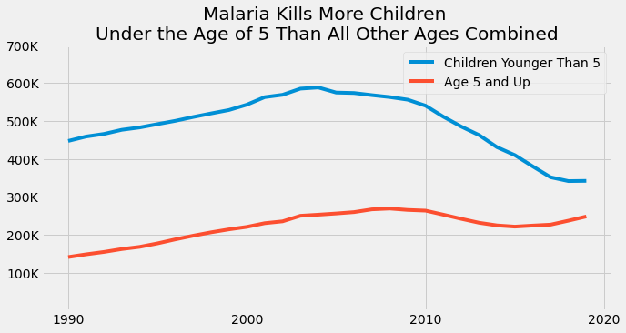

```python
mal_age_compare.plot(x='Year',y=['Deaths-Under-5','Deaths-5-Plus'],figsize=(10,5))

plt.title("Malaria Kills More Children \nUnder the Age of 5 Than All Other Ages Combined")
plt.legend(['Children Younger Than 5','Age 5 and Up'])
plt.xlabel('')

ax = plt.gca()
ax.tick_params(axis='both', colors='black', labelsize=14, length=0)

ax.set_yticks([0,100000,200000,300000,400000,500000,600000,700000])

g = ax.get_yticks()
plt.yticks(g[1:])
ax.get_yaxis().set_major_formatter(
    FuncFormatter(lambda y,p: format(str(int(y/1000))+'K')))

ax.set_xticks([1990,2000,2010,2020])
ax.set_ylim(bottom=0)


plt.show()
```

### Get the 5 countries with the highest death rates for various years and compare results

```python
mal_1990 = mal_rate.loc[mal_rate['Year'] == 1990].sort_values(by="DeathRate", ascending=False)
mal_1990 = list(mal_1990['Entity'].head(5))
mal_1990
```

```
['Sierra Leone', 'Mozambique', 'Burkina Faso', "Cote d'Ivoire", 'Uganda']
```

```python
mal_2000 = mal_rate.loc[mal_rate['Year'] == 2000].sort_values(by="DeathRate", ascending=False)
mal_2000 = list(mal_2000['Entity'].head(5))
mal_2000
```

```
['Sierra Leone', 'Senegal', 'Burkina Faso', 'Liberia', "Cote d'Ivoire"]
```

```python
mal_2010 = mal_rate.loc[mal_rate['Year'] == 2010].sort_values(by="DeathRate", ascending=False)
mal_2010 = list(mal_2010['Entity'].head(5))
mal_2010
```

```
['Sierra Leone', 'Burkina Faso', "Cote d'Ivoire", 'Niger', 'Nigeria']
```

```python
mal_2019 = mal_rate.loc[mal_rate['Year'] == 2019].sort_values(by="DeathRate", ascending=False)
mal_2019 = list(mal_2019['Entity'].head(5))
mal_2019
```

```
['Sierra Leone', "Cote d'Ivoire", 'Liberia', 'Burkina Faso', 'Benin']
```

```python
set(mal_1990) & set(mal_2000) & set(mal_2010) & set(mal_2019)
```

```
{'Burkina Faso', "Cote d'Ivoire", 'Sierra Leone'}
```

```python
malaria_10_19 = mal_rate.loc[(mal_rate['Year'] == 2010) | (mal_rate['Year'] == 2019)]
malaria_10_19.head()
```

|  | Entity | Year | DeathRate |
| --- | --- | --- | --- |
| 20 | Afghanistan | 2010 | 1.56 |
| 29 | Afghanistan | 2019 | 1.66 |
| 50 | African Region (WHO) | 2010 | 87.41 |
| 59 | African Region (WHO) | 2019 | 58.22 |
| 80 | Albania | 2010 | 0.00 |

```python
malaria_10_19.isna().any()
```

```
Entity       False
Year         False
DeathRate    False
dtype: bool
```

```python
malariaX = (malaria_10_19[['Entity']].join(malaria_10_19.groupby('Entity')['DeathRate'].pct_change().mul(100).rename('Percent Death Increase'))
                  .dropna())
print (malariaX)
```

```
                              Entity  Percent Death Increase
29                       Afghanistan                6.410256
59              African Region (WHO)              -33.394348
209                           Angola               -4.376528
389                       Azerbaijan             -100.000000
479                       Bangladesh              -98.076923
...                              ...                     ...
6719  World Bank Lower Middle Income              -34.401832
6749  World Bank Upper Middle Income                8.333333
6779                           Yemen               -6.641124
6809                          Zambia              -16.273187
6839                        Zimbabwe              -61.530945

[98 rows x 2 columns]
```

```python
m_list = malariaX.sort_values(by='Percent Death Increase', ascending=True).round(2).head(25)
m_list
```

|  | Entity | Percent Death Increase |
| --- | --- | --- |
| 5939 | Thailand | -100.00 |
| 389 | Azerbaijan | -100.00 |
| 689 | Bhutan | -100.00 |
| 719 | Bolivia | -100.00 |
| 5519 | South Korea | -100.00 |
| 4619 | Paraguay | -100.00 |
| 1319 | Costa Rica | -100.00 |
| 4019 | Nepal | -100.00 |
| 5969 | Timor | -99.97 |
| 479 | Bangladesh | -98.08 |
| 3929 | Myanmar | -97.64 |
| 6479 | Vanuatu | -97.63 |
| 1649 | East Asia & Pacific (WB) | -91.09 |
| 5729 | Suriname | -91.03 |
| 2699 | Indonesia | -90.67 |
| 4679 | Philippines | -89.19 |
| 1619 | Dominican Republic | -89.13 |
| 3119 | Laos | -88.74 |
| 6539 | Vietnam | -87.23 |
| 959 | Cambodia | -84.62 |
| 5399 | Solomon Islands | -80.48 |
| 2549 | Haiti | -79.73 |
| 2519 | Guyana | -76.41 |
| 1199 | Colombia | -73.33 |
| 1229 | Comoros | -70.78 |